# Object

## Object class

There is one special class in Java - **Object** class. All other classes are subclasses of **Object**. This means that a reference variable of type **Object** can refer to an object of any other class. Also, since arrays are implemented as classes, a variable of type **Object** can also refer to any array.

Object defines the following methods, which means that they are available in every object.

```
Object clone() - Creates a new object that is the same as the object being cloned.
boolean equals(Object obj) - Determines whether one object is equal to another.
void finalize() - Deprecated. Used for destroying objects.
Class getClass() - obtains a class of an object at run time
int hashCode() - returns the hashcode of the associated object
void notify() - resumes execution of a thread waiting on the invoking object.
void notifyAll() - resumes execution of all threads waiting on the invoking object.
String toString() - returns a String that describes the object.
void wait() - wait on another thread of execution.
```

The methods getClass( ), notify( ), notifyAll( ), and wait( ) are declared as final. You may override the others.

### clone() method

The clone() method generates a duplicate copy of the object on which it is called. Only classes that implement the Cloneable interface can be cloned.

The Cloneable interface defines no members. It is used to indicate that a class allows an exact copy of an object (that is, a clone) to be made. If you try to call clone( ) on a class that does not implement Cloneable, a CloneNotSupportedException is thrown. When a clone is made, the constructor for the object being cloned is not called. As implemented by Object, a clone is simply an exact copy of the original.

```java
class A {

}

A a1 = new A();
A a2 = a1.clone();
```

```
|   A a2 = a1.clone();
clone() has protected access in java.lang.Object

|   A a2 = a1.clone();
incompatible types: java.lang.Object cannot be converted to A
```

```java
class A implements Cloneable {

    public int a = 5;
    public int b = 10;

    public Object clone() {
        try {
            return super.clone();
        } catch (CloneNotSupportedException ex) {
            // System.out.println("Cloning not allowed");
            return null;
        }
    }

    public boolean equals(Object o) {
        if (o == null) return false;
        if (this == o) return true;
        if (getClass() != o.getClass())return false;
        A myA = (A) o;

        return this.a == myA.a && this.b == myA.b;
    }
}

A a1 = new A();
A a2 = (A)a1.clone();
System.out.println(a1 == a2);
System.out.println(a1.equals(a2));
```

```
false
true
```

The side effects caused by cloning are sometimes difficult to see at first. It is easy to think that a class is safe for cloning when it actually is not. In general, you should not implement Cloneable for any class without good reason.

### equals() method

When you create a new class, it automatically inherits class Object . If you don’t override equals(), you’ll get Object s equals() method. By default this compares addresses, so only if you are comparing the exact same objects will you get true.

```java
class EqualsDemo {

}

EqualsDemo d1 = new EqualsDemo();
EqualsDemo d2 = new EqualsDemo();
EqualsDemo d3 = d2;

System.out.println(d1 == d2);
System.out.println(d2 == d3);
```

```
false
true
```

Typically, if two objects are the same type and have fields with identical values, you’ll consider those objects equal, but there may also be fields that you don’t want to include in the equals() comparison.

A proper equals() must satisfy the following five conditions:

1. Reflexive: For any x , x.equals(x) should return true
1. Symmetric: For any x and y , x.equals(y) should return true if and only if y.equals(x) returns true .
1. Transitive: For any x, y, and z, if x.equals(y) returns true and y.equals(z) returns true , then x.equals(z) should return true.
1. Consistent: For any x and y , multiple invocations of x.equals(y) consistently return true or consistently return false, provided no information used in equals comparisons on the object is modified.
1. For any non- null x , x.equals(null) should return false .

```java
class Container {
    int width;
    int length;
    String alias;

    public Container(int width, int length, String alias) {
        this.width = width;
        this.length = length;
        this.alias = alias;
    }

    public int getWidth() {
        return this.width;
    }

    public int getLength() {
        return this.length;
    }

    @Override
    public boolean equals(Object o) {
        if (o == null) return false;
        if (o == this) return true;
        if (!(o instanceof Container)) return false;
        Container c = (Container) o;

        return this.width == c.getWidth() && this.length == c.getLength();
    }
}
```

```java
Container c1 = new Container(10, 10, "My Figure");
Container c2 = new Container(10, 10, "Another Figure");
Container c3 = new Container(10, 20, "My Figure");
```

```java
System.out.println(c1.equals(c2));
```

```
true
```

```java
System.out.println(c2.equals(c3));
```

```
false
```

### hashCode method()

A hash code is an integer that is derived from an object. If x and y are two distinct objects, there should be a high probability that x.hashCode() and y.hashCode() are different.

Here is an example of different hashcodes for different strings:

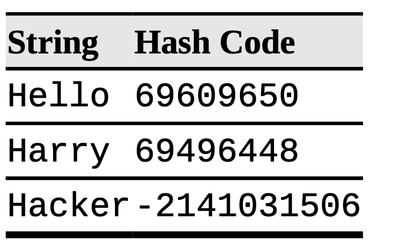

The String class uses the following algorithm to compute the hash code:

```java
int hash = 0;
for (int i = 0; i < "Hello".length(); i++) {
    hash = 31 * hash + "Hello".charAt(i);
}
hash
```

```
69609650
```

Every object has a default hash code. That hash code is derived from the object’s memory address.

If you redefine the equals method, you will also need to redefine the hashCode method for objects that users might insert into a hash table. The hashCode method should return an integer (which can be negative). Just combine the hash codes of the instance fields so that the hash codes for different objects are likely to be widely scattered.

```java
public class Employee {
    String name = "Dima";
    int age = 10;
    double salary = 100000.0;

    @Override
    public int hashCode() {
        return (7 * name.hashCode() + 11 * new Double(salary).hashCode() + age * 21);
    }
}
```

```java
Employee employee = new Employee();
System.out.println(employee.hashCode());
```

```
-879749727
```

However, you can do better. First, use the null-safe method Objects.hashCode. It returns 0 if its argument is null and the result of calling hashCode on the argument otherwise. Also, use the static Double.hashCode method to avoid creating a Double object:

```java
public class Employee {
    String name;
    int age = 10;
    double salary = 1000.0;

    public int hashCode() {
        return 7 * Objects.hashCode(name)
            + 11 * Double.hashCode(salary)
            + 13 * Objects.hashCode(age);
    }
}
```

```java
Employee employee1 = new Employee();
System.out.println(employee1.hashCode());
```

```
-970473342
```

Even better, when you need to combine multiple hash values, call Objects.hash with all of them.

```
public int hashCode(){
    return Objects.hash(name, salary, hireDay);
}
```

Your definitions of equals and hashCode must be compatible: If x.equals(y) is true, then x.hashCode() must return the same value as y.hashCode(). For example, if you define Employee.equals to compare employee IDs, then the hashCode method needs to hash the IDs, not employee names or memory addresses.

### toString() method

Another important method in Object is the toString method that returns a string representing the value of this object.

```java
public class Employee {

    String name;
    int age;
    double salary;

    public Employee(String name, int age, double salary) {
        this.name = name;
        this.age = age;
        this.salary = salary;
    }

    @Override
    public String toString() {
        return "Employee[name=" + name
         + ",salary=" + salary
         + ",age=" + age
         + "]";

    }
}
```

```java
Employee e = new Employee("Dima", 31, 10000);
System.out.println(e);
```

```
Employee[name=Dima,salary=10000.0,age=31]
```